# salmon outmigrant phenology

### first flush timing

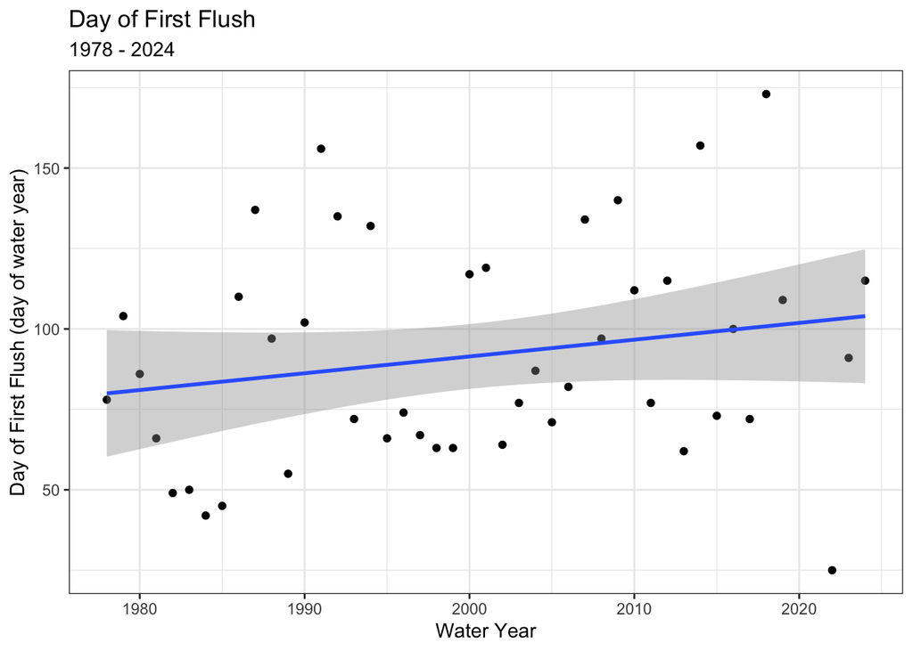

```r
# does the timing of the ff events change over time?
ff_data %>%
  filter(percentile == "day_10", region == "Central Delta") %>%
  ggplot(aes(x = wy, y = ff_wyd)) +
  geom_point() +
  geom_smooth(method = "lm", se = TRUE) +
  labs(title = "Day of First Flush",
       subtitle = "1978 - 2024",
       x = "Water Year",
       y = "Day of First Flush (day of water year)") +
  theme_bw()
```

```r
lm_ff_annual <-
  lm(data = ff_data %>%
       # ensure we aren't pseudo-replicating
       filter(percentile == "day_10", region == "Central Delta"),
     ff_wyd ~ wy)

summary(lm_ff_annual) # no. there's a slope but way noisy
```

```
Call:
lm(formula = ff_wyd ~ wy, data = ff_data %>% filter(percentile ==
    "day_10", region == "Central Delta"))

Residuals:
    Min      1Q  Median      3Q     Max
-77.919 -26.267  -6.528  23.514  72.168

Coefficients:
             Estimate Std. Error t value Pr(>|t|)
(Intercept) -951.9378   756.5819  -1.258    0.215
wy             0.5217     0.3783   1.379    0.175

Residual standard error: 33.52 on 43 degrees of freedom
Multiple R-squared:  0.04236,   Adjusted R-squared:  0.02009
F-statistic: 1.902 on 1 and 43 DF,  p-value: 0.175
```

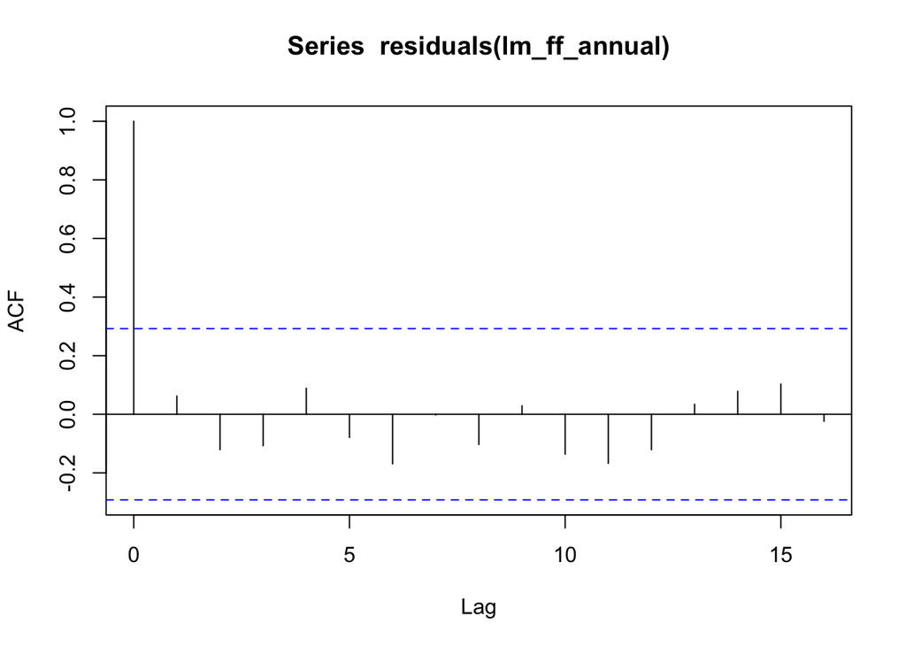

```r
# evidence of autocorrelation?
acf(residuals(lm_ff_annual))
```

```r
# nope

# what's the potential role of water year type here, given that it's almost
# certainly correlated with the timing of first flush events?
lm_ff_wyt <- lm(
  data = ff_data %>%
    filter(percentile == "day_10", region == "Central Delta"),
  ff_wyd ~ wy + wyt
)
summary(lm_ff_wyt)
```

```
Call:
lm(formula = ff_wyd ~ wy + wyt, data = ff_data %>% filter(percentile ==
    "day_10", region == "Central Delta"))

Residuals:
   Min     1Q Median     3Q    Max
-90.89 -16.85  -4.48  26.21  53.52

Coefficients:
             Estimate Std. Error t value Pr(>|t|)
(Intercept) -655.7058   726.5932  -0.902   0.3724
wy             0.3753     0.3632   1.033   0.3078
wyt.L        -23.2644     9.8488  -2.362   0.0233 *
wyt.Q        -12.3721    10.7844  -1.147   0.2583
wyt.C         -8.8604    10.8652  -0.815   0.4197
wyt^4         15.6926    12.2964   1.276   0.2094
---
Signif. codes:  0 '***' 0.001 '**' 0.01 '*' 0.05 '.' 0.1 ' ' 1

Residual standard error: 31.37 on 39 degrees of freedom
Multiple R-squared:  0.2392,    Adjusted R-squared:  0.1417
F-statistic: 2.452 on 5 and 39 DF,  p-value: 0.05027
```

```r
# let's compare these models
AIC(lm_ff_annual, lm_ff_wyt)
```

```
             df      AIC
lm_ff_annual  3 447.7529
lm_ff_wyt     7 445.3987
```

```r
anova(lm_ff_annual, lm_ff_wyt)
```

```
Analysis of Variance Table

Model 1: ff_wyd ~ wy
Model 2: ff_wyd ~ wy + wyt
  Res.Df   RSS Df Sum of Sq      F  Pr(>F)
1     43 48316
2     39 38385  4    9930.8 2.5225 0.05637 .
---
Signif. codes:  0 '***' 0.001 '**' 0.01 '*' 0.05 '.' 0.1 ' ' 1
```

The plot suggested that *maybe* these events were happening later over time, but the regression analysis shows that, while there is an effect of water year *type* on the timing of first flush, there’s insufficient evidence to suggest that there’s been a change over time. The improvement to the model with the addition of `wyt` is modest (p=0.056), but seems real to me.